# LendingClub Loans Default Prediction

Tianchi Wu

## 0.1 Load the data

First we need to start by loading the data.

```r
lc_raw <- read_csv("LendingClub Data.csv",  skip=1) %>%  #since the first row is a title we want to skip it.
  clean_names() # use janitor::clean_names()
```

# 1 ICE the data: Inspect, Clean, Explore

Any data science engagement starts with ICE. Inspecting, Clean and Explore the data.

## 1.1 Inspect the data

Inspect the data to understand what different variables mean. Variable definitions can be found in the excel version of the data.

```r
glimpse(lc_raw)
```

```
## Rows: 42,538
## Columns: 80
## $ int_rate            <dbl> 0.05, 0.05, 0.05, 0.05, 0.05, 0.05, 0.05, 0.05,...
## $ loan_amnt           <dbl> 8000, 6000, 6500, 8000, 5500, 6000, 10200, 1500...
## $ term_months         <dbl> 36, 36, 36, 36, 36, 36, 36, 36, 36, 36, 36, 36,...
## $ installment         <dbl> 241.3, 181.0, 196.0, 241.3, 165.9, 181.0, 307.6...
## $ dti                 <dbl> 2.11, 5.73, 17.68, 22.71, 5.75, 21.92, 18.62, 9...
## $ delinq_2yrs         <dbl> 0, 0, 0, 0, 0, 0, 0, 0, 0, 0, 0, 0, 0, 0, 0, 0,...
## $ annual_inc          <dbl> 50000, 52800, 35352, 79200, 240000, 89000, 1100...
## $ grade               <chr> "A", "A", "A", "A", "A", "A", "A", "A", "A", "A...
## $ emp_title           <chr> NA, "coral graphics", NA, "Honeywell", "O T Plu...
## $ emp_length          <chr> "5 years", "< 1 year", "n/a", "n/a", "10+ years...
## $ home_ownership      <chr> "MORTGAGE", "MORTGAGE", "MORTGAGE", "MORTGAGE",...
## $ verification_status <chr> "Verified", "Source Verified", "Not Verified", ...
## $ issue_d             <chr> "9/1/2011", "9/1/2011", "9/1/2011", "9/1/2011",...
```

[output cut: 67 more lines]

## 1.2 Clean the data

Are there any redundant columns and rows? Are all the variables in the correct format (e.g., numeric, factor, date)? Lets fix it.

The variable “loan_status” contains information as to whether the loan has been repaid or charged off (i.e., defaulted). Let’s create a binary factor variable for this. This variable will be the focus of this workshop.

```r
lc_clean<- lc_raw %>%
  dplyr::select(-x20:-x80) %>% #delete empty columns
  filter(!is.na(int_rate)) %>%   #delete empty rows
  mutate(
    issue_d = mdy(issue_d),  # lubridate::mdy() to fix date format
    term = factor(term_months),     # turn 'term' into a categorical variable
    delinq_2yrs = factor(delinq_2yrs) # turn 'delinq_2yrs' into a categorical variable
  ) %>%
  mutate(default = dplyr::recode(loan_status,
                      "Charged Off" = "1",
                      "Fully Paid" = "0"))%>%
    mutate(default = as.factor(default)) %>%
  dplyr::select(-emp_title,-installment, -term_months, everything()) #move some not-so-important variables to the end.
```

## 1.3 Explore the data

Let’s explore loan defaults by creating different visualizations. We start with examining how prevalent defaults are, whether the default rate changes by loan grade or number of delinquencies, and a couple of scatter plots of defaults against loan amount and income.

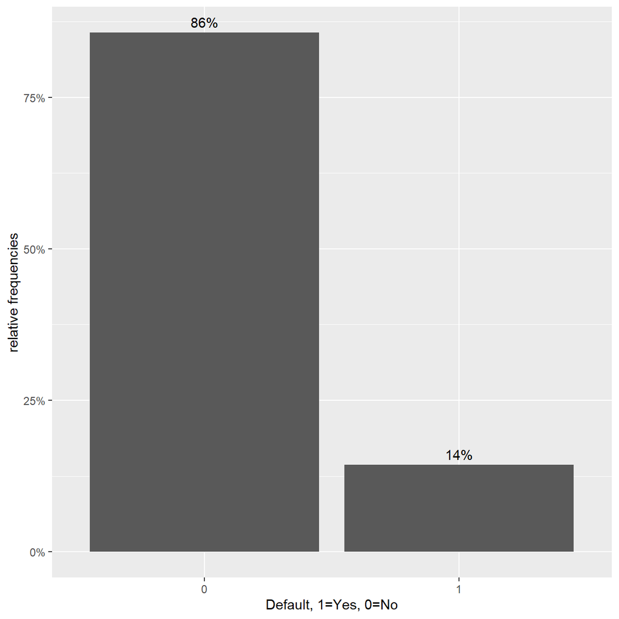

```r
#bar chart of defaults
def_vis1<-ggplot(data=lc_clean, aes(x=default)) +geom_bar(aes(y = (..count..)/sum(..count..))) + labs(x="Default, 1=Yes, 0=No", y="relative frequencies") +scale_y_continuous(labels=scales::percent) +geom_text(aes( label = scales::percent((..count..)/sum(..count..) ),y=(..count..)/sum(..count..) ), stat= "count",vjust=-0.5)
def_vis1
```

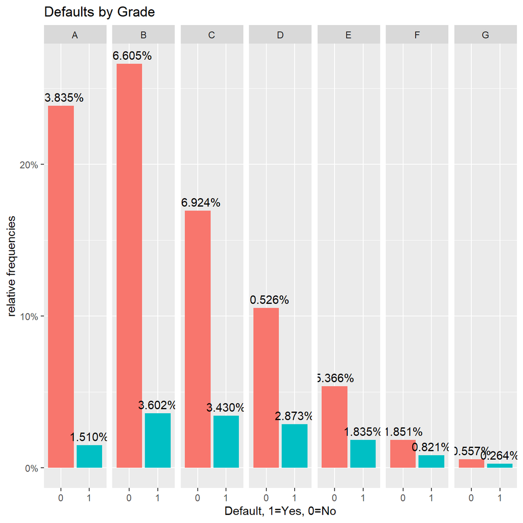

```r
#bar chart of defaults per loan grade
def_vis2<-ggplot(data=lc_clean, aes(x=default), group=grade) +geom_bar(aes(y = (..count..)/sum(..count..), fill = factor(..x..)), stat="count")  + labs(title="Defaults by Grade", x="Default, 1=Yes, 0=No", y="relative frequencies") +scale_y_continuous(labels=scales::percent) +facet_grid(~grade) + theme(legend.position = "none") +geom_text(aes( label = scales::percent((..count..)/sum(..count..) ),y=(..count..)/sum(..count..) ), stat= "count",vjust=-0.5)
def_vis2
```

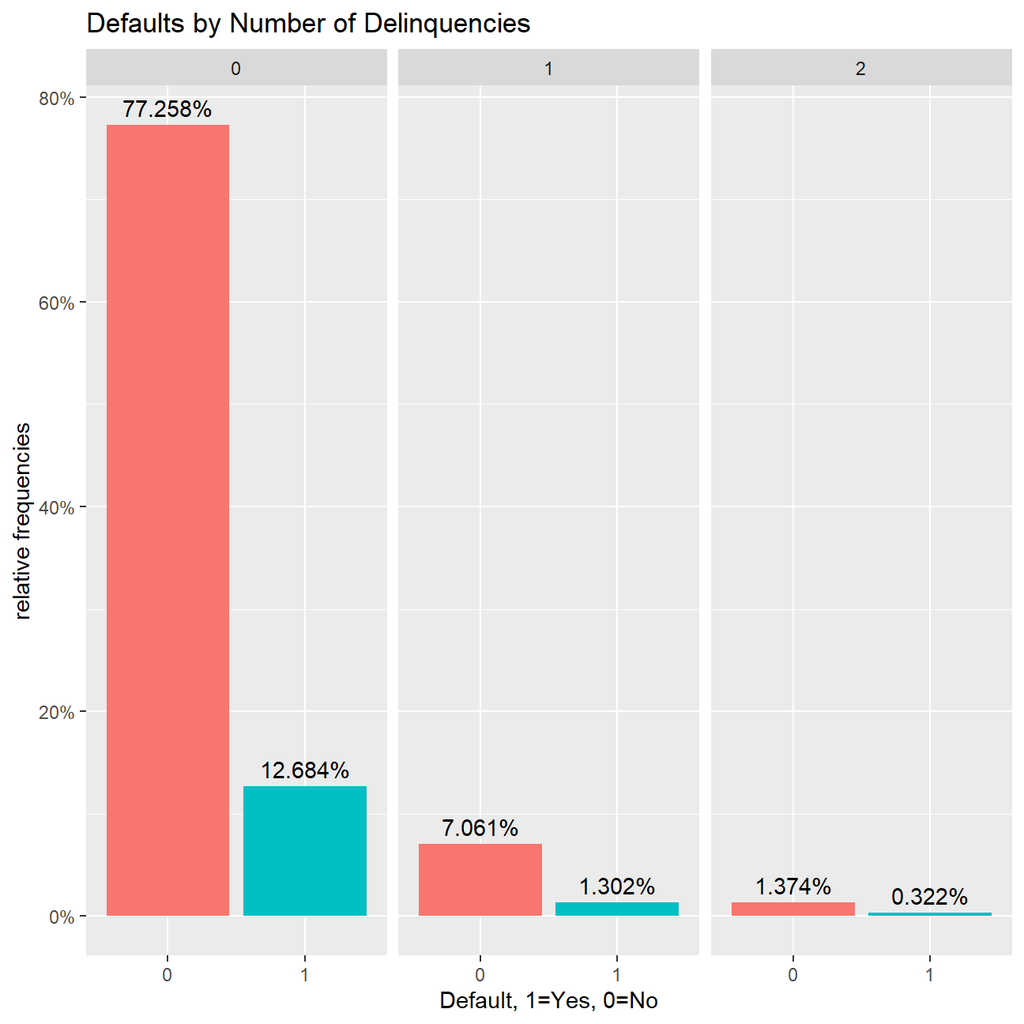

```r
#bar chart of defaults per number of Delinquencies
def_vis3<-lc_clean %>%
  filter(as.numeric(delinq_2yrs)<4) %>%
  ggplot(aes(x=default), group=delinq_2yrs) +geom_bar(aes(y = (..count..)/sum(..count..), fill = factor(..x..)), stat="count")  + labs(title="Defaults by Number of Delinquencies", x="Default, 1=Yes, 0=No", y="relative frequencies")  +scale_y_continuous(labels=scales::percent) +facet_grid(~delinq_2yrs) + theme(legend.position = "none") +geom_text(aes( label = scales::percent((..count..)/sum(..count..) ),y=(..count..)/sum(..count..) ), stat= "count",vjust=-0.5)

def_vis3
```

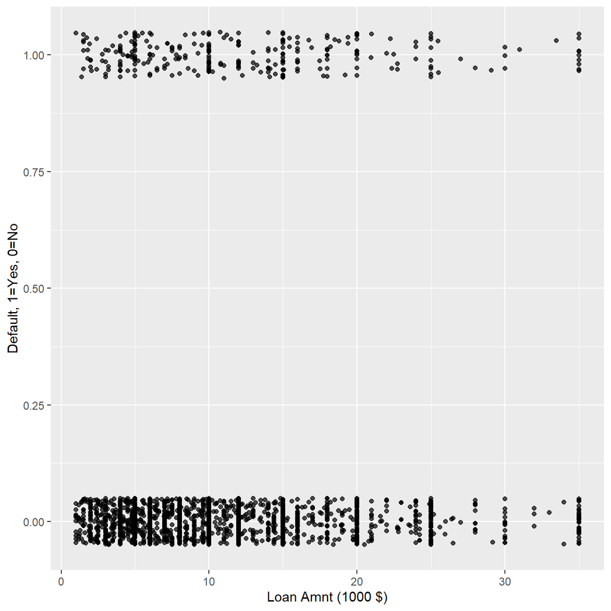

```r
#scatter plots

#We select 2000 random loans to display only to make the display less busy.
set.seed(1234)
reduced<-lc_clean[sample(0:nrow(lc_clean), 2000, replace = FALSE),]%>%
  mutate(default=as.numeric(default)-1) # also convert default to a numeric {0,1} to make it easier to plot.


# scatter plot of defaults against loan amount
def_vis4<-ggplot(data=reduced, aes(y=default,x=I(loan_amnt/1000)))  + labs(y="Default, 1=Yes, 0=No", x="Loan Amnt (1000 $)") +geom_jitter(width=0, height=0.05, alpha=0.7) #We use jitter to offset the display of defaults/non-defaults to make the data easier to interpert. We have also changed the amount to 1000$ to reduce the number of zeros on the horizontal axis.

def_vis4
```

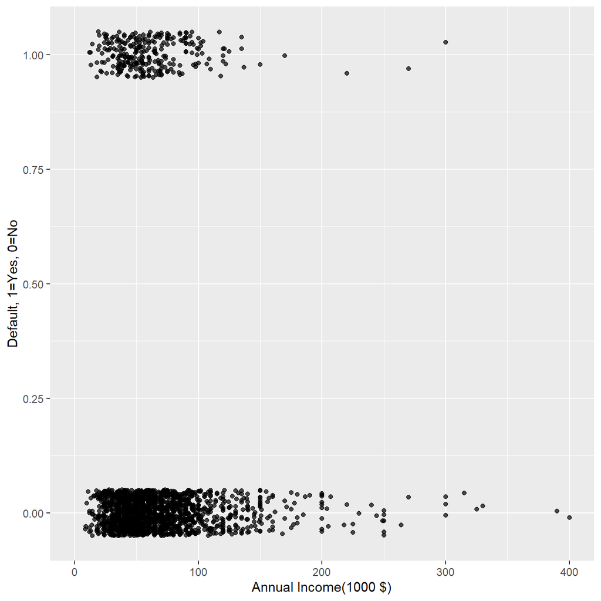

```r
#scatter plot of defaults against loan amount.
def_vis5<-ggplot(data=reduced, aes(y=default,x=I(annual_inc/1000)))   + labs(y="Default, 1=Yes, 0=No", x="Annual Income(1000 $)") +geom_jitter(width=0, height=0.05, alpha=0.7) +  xlim(0,400)

def_vis5
```

We can also estimate a correlation table between defaults and other continuous variables.

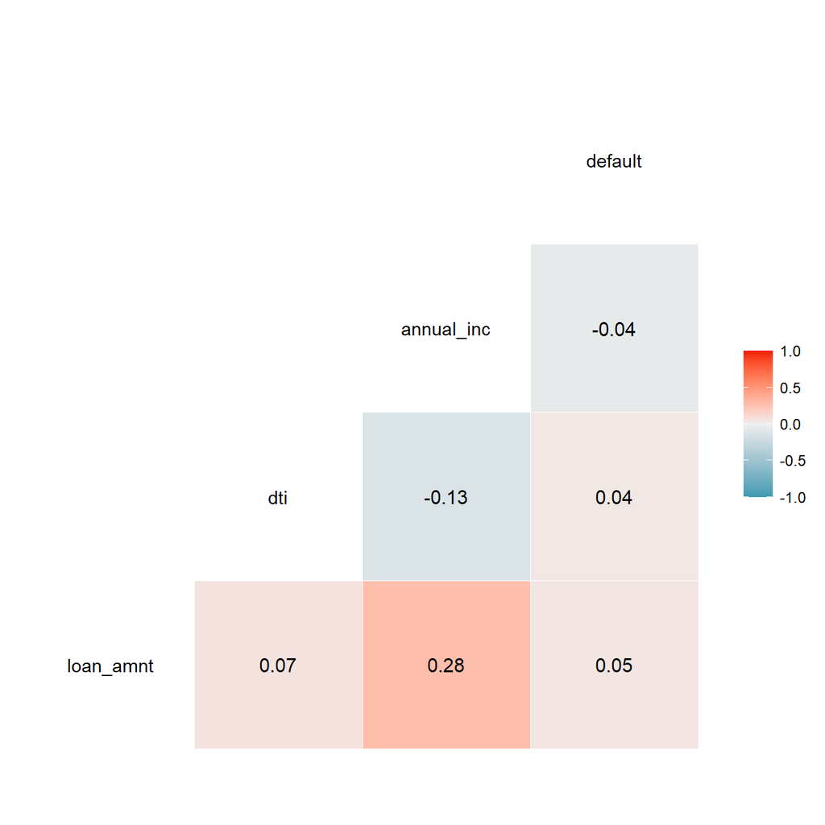

```r
# correlation table using GGally::ggcor()
# this takes a while to plot

lc_clean %>%
    mutate(default=as.numeric(default)-1)%>%
  select(loan_amnt, dti, annual_inc, default) %>% #keep Y variable last
 ggcorr(method = c("pairwise", "pearson"), label_round=2, label = TRUE)
```

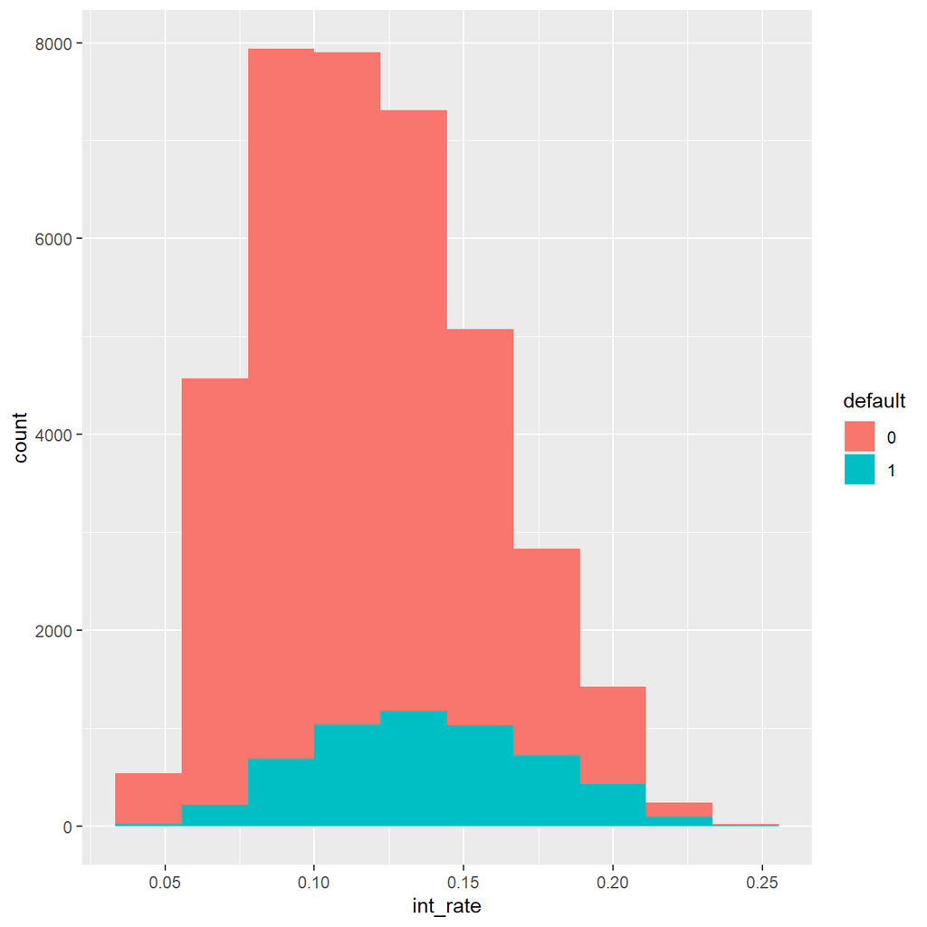

```r
# My visualization
lc_clean %>% ggplot(aes( x = int_rate, fill  = default)) + geom_histogram(bins= 10)
```

We have already explored relationships between default with loan amount and annual income. Here I made another histogram to find out whether interest rate will effect default. It seems from this graph that, when interest rates are higher than 0.15, the percentage of default increases.

# 2 Linear vs. logistic regression for binary response variables

It is certainly possible to use the OLS approach to find the line that minimizes the sum of square errors when the dependent variable is binary (i.e., default no default). In this case, the predicted values take the interpretation of a probability. We can also estimate a logistic regression instead. We do both below.

```r
model_lm<-lm(as.numeric(default)~I(annual_inc/1000), lc_clean)
summary(model_lm)
```

```
##
## Call:
## lm(formula = as.numeric(default) ~ I(annual_inc/1000), data = lc_clean)
##
## Residuals:
##    Min     1Q Median     3Q    Max
## -0.160 -0.149 -0.144 -0.133  1.327
##
## Coefficients:
##                     Estimate Std. Error t value Pr(>|t|)
## (Intercept)         1.16e+00   2.70e-03   429.3   <2e-16 ***
## I(annual_inc/1000) -2.48e-04   2.92e-05    -8.5   <2e-16 ***
## ---
## Signif. codes:  0 '***' 0.001 '**' 0.01 '*' 0.05 '.' 0.1 ' ' 1
##
## Residual standard error: 0.35 on 37867 degrees of freedom
## Multiple R-squared:  0.0019, Adjusted R-squared:  0.00188
## F-statistic: 72.2 on 1 and 37867 DF,  p-value: <2e-16
```

```r
logistic1<-glm(default~I(annual_inc/1000), family="binomial", lc_clean)
summary(logistic1)
```

```
##
## Call:
## glm(formula = default ~ I(annual_inc/1000), family = "binomial",
##     data = lc_clean)
##
## Deviance Residuals:
##    Min      1Q  Median      3Q     Max
## -0.625  -0.579  -0.557  -0.511   3.639
##
## Coefficients:
##                    Estimate Std. Error z value Pr(>|z|)
## (Intercept)        -1.51916    0.02924   -52.0   <2e-16 ***
## I(annual_inc/1000) -0.00408    0.00040   -10.2   <2e-16 ***
## ---
## Signif. codes:  0 '***' 0.001 '**' 0.01 '*' 0.05 '.' 0.1 ' ' 1
##
## (Dispersion parameter for binomial family taken to be 1)
##
##     Null deviance: 31130  on 37868  degrees of freedom
## Residual deviance: 31005  on 37867  degrees of freedom
## AIC: 31009
##
## Number of Fisher Scoring iterations: 5
```

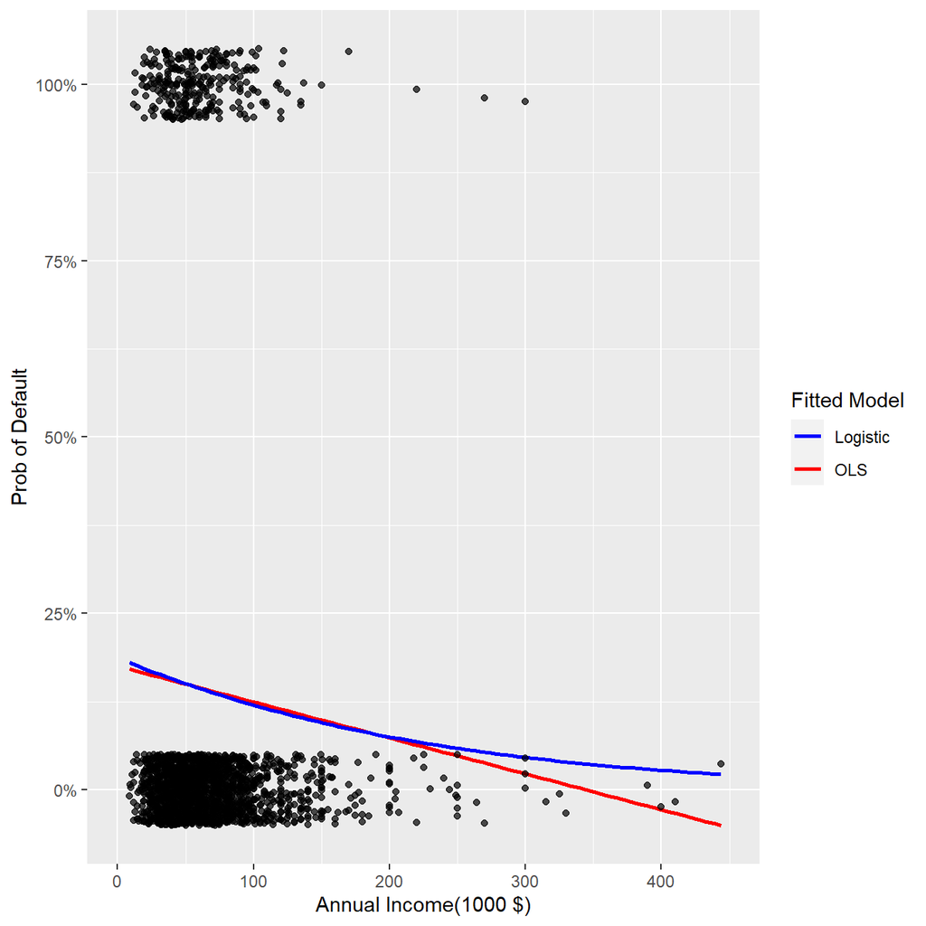

```r
ggplot(data=reduced, aes(x=I(annual_inc/1000), y=default)) + geom_smooth(method="lm", se=0, aes(color="OLS"))+ geom_smooth(method = "glm", method.args = list(family = "binomial"),  se=0, aes(color="Logistic"))+ labs(y="Prob of Default", x="Annual Income(1000 $)")+  xlim(0,450)+scale_y_continuous(labels=scales::percent)+geom_jitter(width=0, height=0.05, alpha=0.7) + scale_colour_manual(name="Fitted Model", values=c("blue", "red"))
```

The logistic regression is more suitable for predicting probability of default since linear regression model’s line has already passed through zero - means that an individual having more than 350,000 annual income would have a negative probability of default, which goes against the reality apparently.

# 3 Multivariate logistic regression

We can estimate logistic regression with multiple explanatory variables as well. Let’s use annual_inc, term, grade, and loan amount as features. Let’s call this model logistic 2.

```r
logistic2<- glm(default~I(annual_inc/1000) + term + grade + loan_amnt, family="binomial", lc_clean)
summary(logistic2)
```

```
##
## Call:
## glm(formula = default ~ I(annual_inc/1000) + term + grade + loan_amnt,
##     family = "binomial", data = lc_clean)
##
## Deviance Residuals:
##    Min      1Q  Median      3Q     Max
## -1.063  -0.608  -0.482  -0.345   4.099
##
## Coefficients:
##                     Estimate Std. Error z value Pr(>|z|)
## (Intercept)        -2.43e+00   5.06e-02  -48.09   <2e-16 ***
## I(annual_inc/1000) -6.02e-03   4.73e-04  -12.73   <2e-16 ***
## term60              4.79e-01   3.56e-02   13.45   <2e-16 ***
## gradeB              6.60e-01   5.27e-02   12.52   <2e-16 ***
## gradeC              1.03e+00   5.39e-02   19.13   <2e-16 ***
## gradeD              1.29e+00   5.70e-02   22.58   <2e-16 ***
## gradeE              1.42e+00   6.66e-02   21.24   <2e-16 ***
## gradeF              1.67e+00   8.63e-02   19.30   <2e-16 ***
## gradeG              1.77e+00   1.34e-01   13.20   <2e-16 ***
## loan_amnt           2.84e-06   2.35e-06    1.21     0.23
## ---
## Signif. codes:  0 '***' 0.001 '**' 0.01 '*' 0.05 '.' 0.1 ' ' 1
##
## (Dispersion parameter for binomial family taken to be 1)
##
##     Null deviance: 31130  on 37868  degrees of freedom
## Residual deviance: 29286  on 37859  degrees of freedom
## AIC: 29306
##
## Number of Fisher Scoring iterations: 5
```

```r
#compare the fit of logistic 1 and logistic 2
anova(logistic1,logistic2)
```

| Resid. Df | Resid. Dev | Df | Deviance |
| --- | --- | --- | --- |
| 3.79e+04 | 3.1e+04 |  |  |
| 3.79e+04 | 2.93e+04 | 8 | 1.72e+03 |

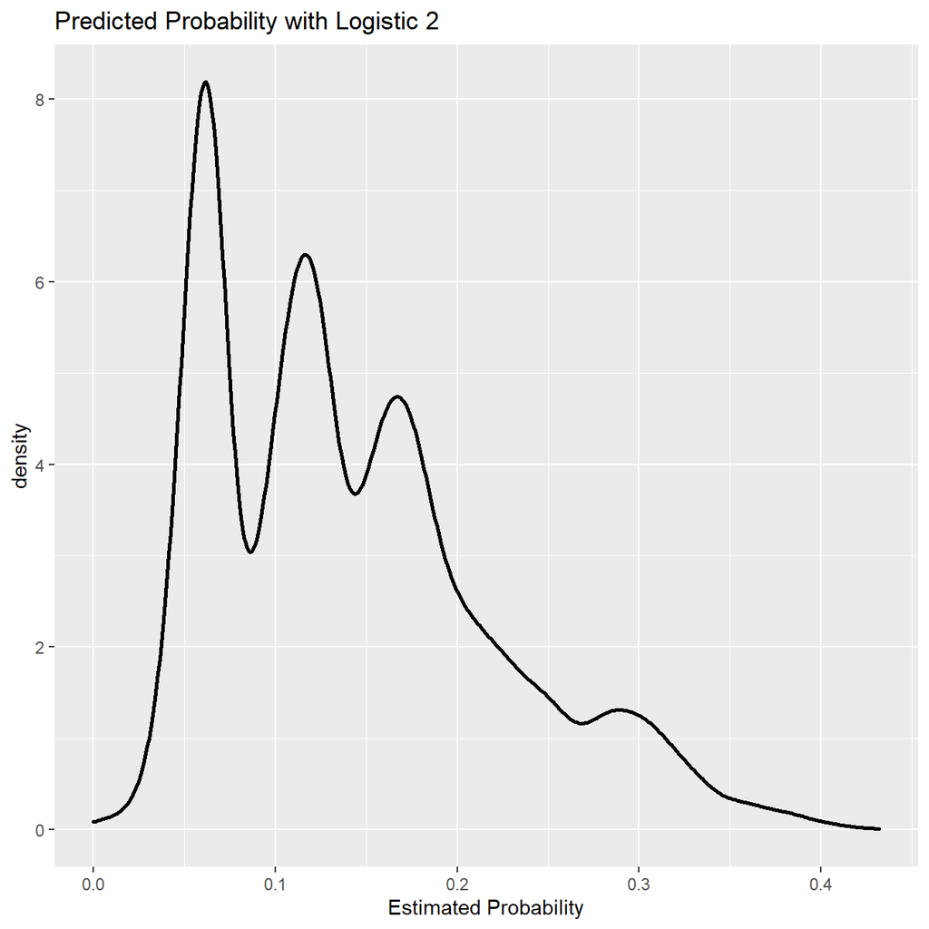

```r
#Predict the probability of default
prob_default2<-predict(logistic2, lc_clean, type= "response")

#plot 1: Density of predictions
g1 <- ggplot(lc_clean, aes(prob_default2)) +
  geom_density(size = 1) +
  ggtitle("Predicted Probability with Logistic 2") +
  xlab("Estimated Probability")

#plot 2: Density of predictions by default
g2 <- ggplot(lc_clean, aes(prob_default2, color = default )) +
  geom_density(size = 1) +
  ggtitle("Predicted Probability with Logistic 2") +
  xlab("Estimated Probability")

g1
```

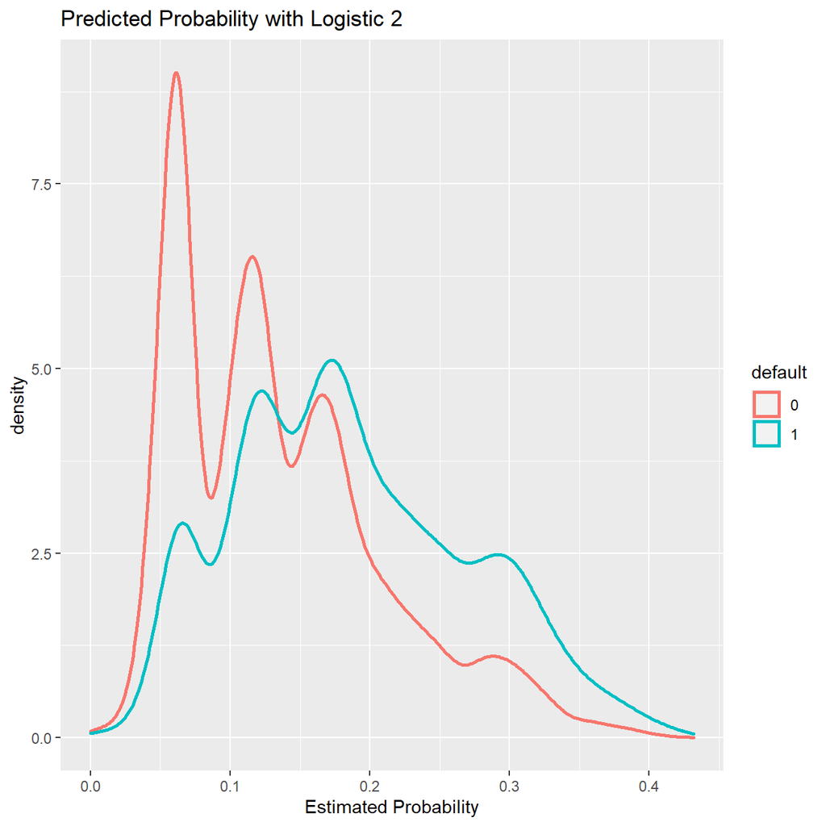

```r
g2
```

## 3.1 From probability to classification

The logistic regression model gives us a sense of how likely defaults are; it gives us a probability estimate. To convert this into a prediction, we need to choose a cutoff probability and classify every loan with a predicted probability of default above the cutoff as a prediction of default (and vice versa for loans with a predicted probability below this cutoff).

```r
library(e1071)
#using the logistic 2 model predict default probabilities
prob_default2<- predict(logistic2, lc_clean, type= "response")
one_or_zero <- ifelse(prob_default2>0.18,"1","0")

#Call any loan with probability more than 18% as defualt and any loan with lower probability as non-default. Make sure your prediction is a factor with the same levels as the default variable in the lc_clean data frame
p_class<-factor(one_or_zero, levels = levels(lc_clean$default))

#produce the confusion matrix and set default as the positive outcome
con2<- confusionMatrix(p_class, lc_clean$default, positive = "1")

#print the confusion matrix
con2
```

```
## Confusion Matrix and Statistics
##
##           Reference
## Prediction     0     1
##          0 24674  2818
##          1  7766  2611
##
##                Accuracy : 0.721
##                  95% CI : (0.716, 0.725)
##     No Information Rate : 0.857
##     P-Value [Acc > NIR] : 1
##
##                   Kappa : 0.175
##
##  Mcnemar's Test P-Value : <2e-16
##
##             Sensitivity : 0.4809
##             Specificity : 0.7606
##          Pos Pred Value : 0.2516
##          Neg Pred Value : 0.8975
##              Prevalence : 0.1434
##          Detection Rate : 0.0689
##    Detection Prevalence : 0.2740
##       Balanced Accuracy : 0.6208
##
##        'Positive' Class : 1
##
```

1. Accuracy is calculated by the total number of correct predictions (both negative and positive) divided by all predictions. Here it stands for how well we predict loans that will default and did default, and loans that will not default and did not default.
2. Sensitivity is calculated by the number of True Positives divided by Positives. Here means our model catches 48.1% of all the bad loans.
3. Specificity is calculated by the number of True Negatives divided by Negatives. Here means our model identifies 76.1% of all the good loans.

> Q7. Using the model logistic 2 produce the ROC curve and calculate the AUC measure. Explain what the ROC shows and what the AUC measure means. Why do we expect the AUC of any predictive model to be between 0.5 and 1? Could the AUC ever be below 0.5 or above 1?

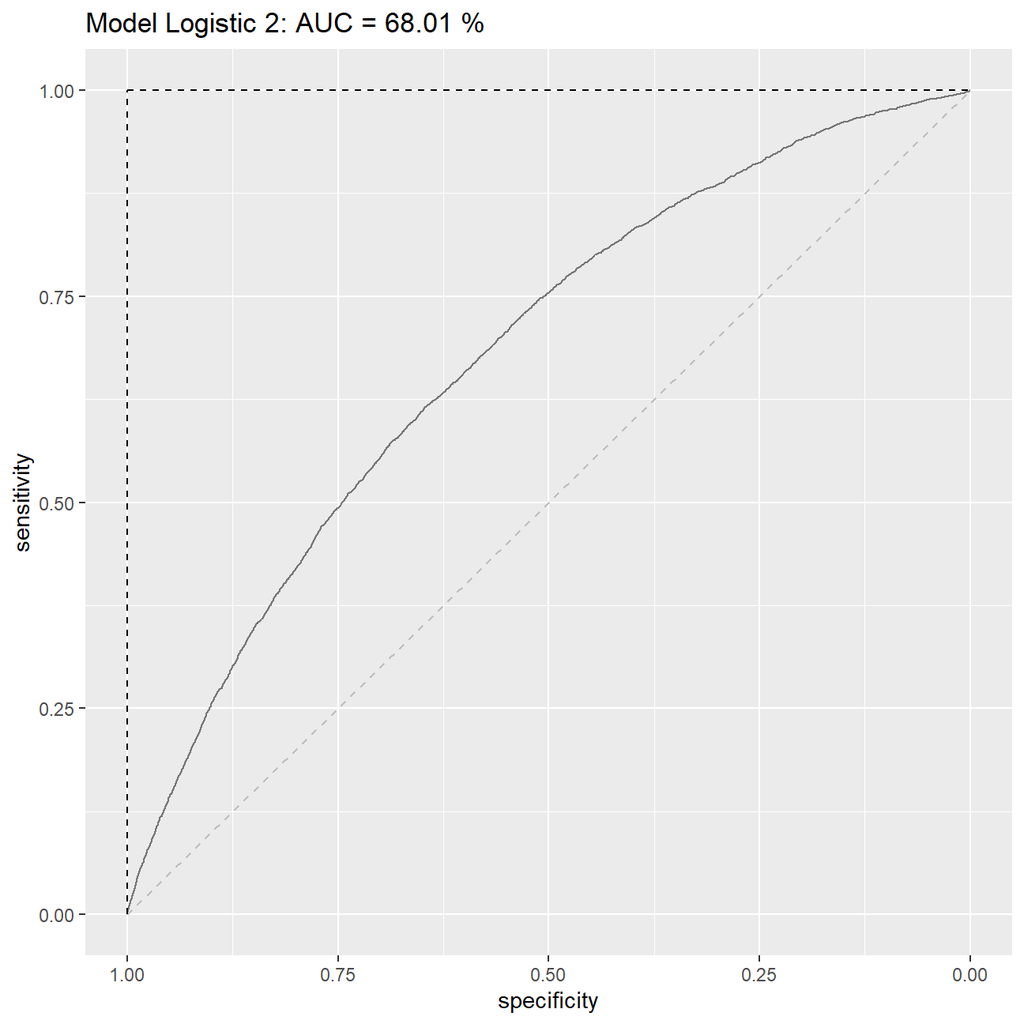

```r
#estimate the ROC curve for Logistic 2
ROC_logistic2 <-roc(lc_clean$default, prob_default2)

#estimate the AUC for Logistic 2 and round it to two decimal places
AUC2<-round(auc(lc_clean$default, prob_default2)*100, digits = 2)
#Plot the ROC curve and display the AUC in the title
ROC2<- ggroc(ROC_logistic2, alpha = 0.5) +
  ggtitle(paste("Model Logistic 2: AUC =", AUC2, "%")) +
    geom_segment(aes(x = 1, xend = 0, y = 0, yend = 1),
               color = "grey", linetype = "dashed") +
    geom_segment(aes(x = 1, xend = 1, y = 0, yend = 1),
               color = "black", linetype = "dashed") +
    geom_segment(aes(x = 1, xend = 0, y = 1, yend = 1),
               color = "black", linetype = "dashed")

ROC2
```

The ROC shows a scatter plot of our model’s sensitivity against the specificity for different cuttoff values. In our graph, for example, if we choose a cutoff value to calculate a specificity of 50%, then we could expect our sensitivity to be 75%.

AUC stands for the area under the curve and can be used to measure the predictive power of the model. Its value must be between [0.5,1] since the lowest predictive power would the case of purely random chance, while the highest predictive power would be the case of 100% sensitivity, specificity and accuracy.

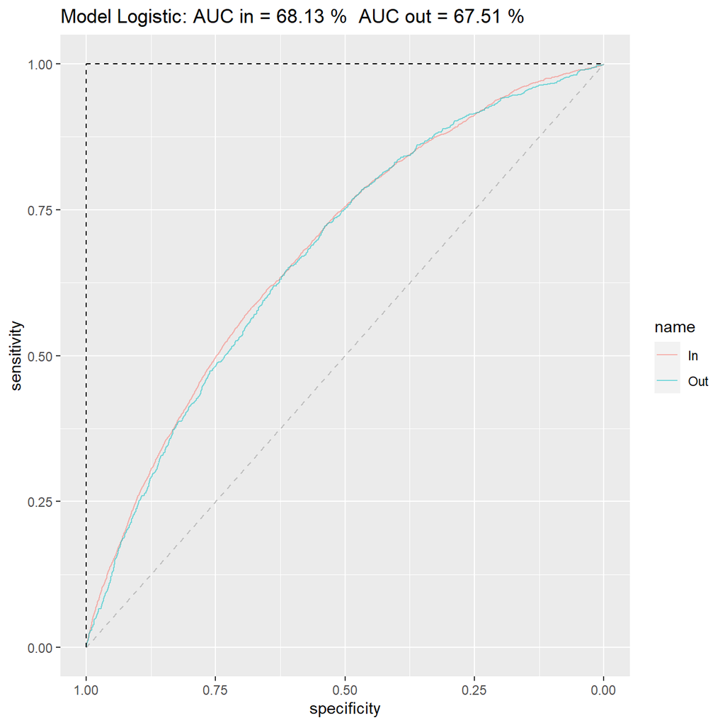

```r
# splitting the data into training and testing
set.seed(1234)
train_test_split <- initial_split(lc_clean, prop = 0.8)
testing <- testing(train_test_split) #20% of the data is set aside for testing
training <- training(train_test_split) #80% of the data is set aside for training

# run logistic 2 on the training set
logistic2<- glm(default~I(annual_inc/1000) + term + grade + loan_amnt, family="binomial", training)

#calculate probability of default in the training sample
p_in<-predict(logistic2, training, type= "response")

#ROC curve using in-sample predictions
ROC_logistic2_in <- roc(training$default, p_in)
#AUC using in-sample predictions
AUC_logistic2_in<-round(auc(training$default, p_in)*100, digits = 2)

#calculate probability of default out of sample
p_out<- predict(logistic2, testing, type= "response")

#ROC curve using out-of-sample predictions
ROC_logistic2_out <- roc(testing$default, p_out)
#AUC using out-of-sample predictions
AUC_logistic2_out <- round(auc(testing$default, p_out)*100, digits = 2)
#plot in the same figure both ROC curves and print the AUC of both curves in the title
ROCin_out<- ggroc(list(In = ROC_logistic2_in, Out = ROC_logistic2_out), alpha = 0.5) +
  ggtitle(paste("Model Logistic: AUC in =", AUC_logistic2_in,"%"," AUC out =", AUC_logistic2_out,"%")) +
    geom_segment(aes(x = 1, xend = 0, y = 0, yend = 1),
               color = "grey", linetype = "dashed") +
    geom_segment(aes(x = 1, xend = 1, y = 0, yend = 1),
               color = "black", linetype = "dashed") +
    geom_segment(aes(x = 1, xend = 0, y = 1, yend = 1),
               color = "black", linetype = "dashed")

ROCin_out
```

Our AUC only decreases 0.6% when we use our model to predict out-of-sample data, so I wouldn’t say there’s much evidence of overfitting.

## 3.2 Selecting loans to invest using the model Logistic 2.

Before we look for a better model than logistic 2 let’s see how we can use this model to select loans to invest. Let’s make the simplistic assumption that every loan generates $20 profit if it is paid off and $100 loss if it is charged off for an investor. Let’s use a cut-off value to determine which loans to invest in, that is, if the predicted probability of default for a loan is below this value then we invest in that loan and not if it is above.

To do this we split the data in three parts: training, validation, and testing. Feel free to experiment with different seeds but please use the seeds provided below for your submission.

```r
# splitting the data into training and testing
set.seed(1234)
train_test_split <- initial_split(lc_clean, prop = 0.6)
training <- training(train_test_split) #60% of the data is set aside for training
remaining <- testing(train_test_split) #40% of the data is set aside for validation & testing
set.seed(4321)
train_test_split <- initial_split(remaining, prop = 0.5)
validation<-training(train_test_split) #50% of the remaining data (20% of total data) will be used for validation
testing<-testing(train_test_split) #50% of the remaining data (20% of total data) will be used for testing
```

```r
# run logistic 2 on the training set
logistic2<- glm(default~I(annual_inc/1000) + term + grade + loan_amnt, family="binomial", training)
#calculate probability of default in the training sample
p_train <-predict(logistic2, training, type= "response")
#calculate probability of the validation set
p_validation <- predict(logistic2, validation, type= "response")

#define the parameters profit and threshold
profit=0
threshold=0
#loop over 100 thresholds
for(i in 1:100) {
  threshold[i]=i/400
  one_or_zero_search<-ifelse(p_validation>threshold[i],"1","0")
  p_class_search<-factor(one_or_zero_search,levels=levels(validation$default))

  con_search<-confusionMatrix(p_class_search,validation$default,positive="1")
  #calculate the profit associated with the threshold
  profit[i]=con_search$table[1,1]*20-con_search$table[1,2]*100
}

data.frame(threshold = threshold * 100, profit = profit) %>% arrange(desc(profit))
```

| threshold | profit |
| --- | --- |
| 15.5 | 4.48e+04 |
| 16.2 | 4.46e+04 |
| 15.2 | 4.45e+04 |
| 15 | 4.43e+04 |
| 16 | 4.42e+04 |
| 16.5 | 4.42e+04 |
| 15.8 | 4.39e+04 |
| 17.5 | 4.38e+04 |
| 14.8 | 4.37e+04 |
| 17.2 | 4.37e+04 |
| 17.8 | 4.36e+04 |
| 16.8 | 4.33e+04 |
| 14.5 | 4.32e+04 |
| 18 | 4.3e+04 |
| 12.8 | 4.3e+04 |
| 17 | 4.3e+04 |
| 14.2 | 4.29e+04 |
| 18.2 | 4.27e+04 |
| 14 | 4.27e+04 |
| 13 | 4.24e+04 |
| 18.5 | 4.24e+04 |
| 12.5 | 4.23e+04 |
| 13.8 | 4.22e+04 |
| 13.2 | 4.21e+04 |
| 13.5 | 4.21e+04 |
| 12.2 | 4.17e+04 |
| 18.8 | 4.16e+04 |
| 19.2 | 4.11e+04 |
| 19 | 4.1e+04 |
| 19.5 | 4.1e+04 |

[output cut: 70 more lines]

The optimal cutoff threshold is 15.5% and generates 44840 dollars of profits. Based on the testing set, profit per loan is $5.4.

```r
#Profit per loan using the testing set - apply the threshold

#optimal threshold based on the validation set
threshold=threshold[which.is.max(profit)]

#Use the model estimated on the training set to predict probabilities of default on the testing set
p_test<-predict(logistic2, testing, type = "response")

#use the threshold estimated using the validation set to estimate the profits on the testing set
one_or_zero<-ifelse(p_test>threshold,"1","0")
p_class<-factor(one_or_zero,levels=levels(testing$default))
con<-confusionMatrix(p_class,testing$default,positive="1")
profit=con$table[1,1]*20-con$table[1,2]*100
paste0("Based on the testing set the actual profit per loan is: $", round(profit/nrow(testing),2))
```

```
## [1] "Based on the testing set the actual profit per loan is: $5.4"
```

# 4 More realistic revenue model

Let’s build a more realistic profit and loss model. Each loan has different terms (e.g., different interest rate and different duration) and therefore a different return if fully paid. For example, a 36 month loan of $5000 with installment of $163 per month would generate a return of `163*36/5000-1` if there was no default. Let’s assume that it would generate a loss of -60% if there was a default (the loss is not 100% because the loan may not default immediately and/or the lending club may be able to recover part of the loan).

```r
#use the threshold estimated using the validation set to estimate the profits on the testing set
one_or_zero<-ifelse(p_validation>threshold,"1","0")
p_class<-factor(one_or_zero,levels=levels(validation$default))
con<-confusionMatrix(p_class,validation$default,positive="1")

total_return_rate = con$table[1,1]*(validation$installment * validation$term_months/validation$loan_amnt -1) -con$table[1,2]*0.6
average_return_rate= mean(total_return_rate/nrow(validation))

#print out our result
sprintf("%1.2f%%", 100*average_return_rate)
```

```
## [1] "10.49%"
```

The average return we could get for the whole 7574 loans in the validation set is 10.49%.

Unfortunately, we cannot use the realized return to select loans to invest (as at the time we make the investment decision we do not know which loan will default). Instead, we can calculate an expected return using the estimated probabilities of default – expected return = return if not default * (1-prob(default)) + return if default * prob(default).

```r
# adding default probability calculated by validation set to our dataframe.
validation$default_prob <- p_validation

# adding a new column of profit calculated in the method above to our dataframe.
validation <- validation %>%
  mutate(profit = (1-default_prob)*(installment * term_months - loan_amnt) - default_prob * 0.6 * loan_amnt)

# selecting the top 800 loans having the most profits.

portfolio_selected <- validation %>%
 arrange(desc(profit)) %>%
 head(800)

paste0("The total profit is when n = 800: $", round(sum(portfolio_selected$profit),2))
```

```
## [1] "The total profit is when n = 800: $4340874.89"
```

If I change the number of loans I choose to a higher level, the realized return will increase as well. The profit for n = 800 is 4340874 dollars.

```r
#loss proportion = 20%
validation$default_prob <- p_validation

validation <- validation %>%
  mutate(profit = (1-default_prob)*(installment * term_months - loan_amnt) - default_prob * 0.2 * loan_amnt)

portfolio_selected <- validation %>%
 arrange(desc(profit)) %>%
 head(800)

paste0("The total profit is when n = 800: $", round(sum(portfolio_selected$profit),2))
```

```
## [1] "The total profit is when n = 800: $6062685.06"
```

```r
#loss proportion = 80%
validation$default_prob <- p_validation

validation <- validation %>%
  mutate(profit = (1-default_prob)*(installment * term_months - loan_amnt) - default_prob * 0.8 * loan_amnt)

portfolio_selected <- validation %>%
 arrange(desc(profit)) %>%
 head(800)

paste0("The total profit is when n = 800: $", round(sum(portfolio_selected$profit),2))
```

```
## [1] "The total profit is when n = 800: $3536667.07"
```

From the result we could see that the higher the loss proportion, the lower return we could get from our portfolio.

```r
# my best model logistic 3:
logistic3 <- glm(default~I(annual_inc/1000) + int_rate + term + loan_amnt*dti + grade, family="binomial", lc_clean)
summary(logistic3)
```

```
##
## Call:
## glm(formula = default ~ I(annual_inc/1000) + int_rate + term +
##     loan_amnt * dti + grade, family = "binomial", data = lc_clean)
##
## Deviance Residuals:
##    Min      1Q  Median      3Q     Max
## -1.137  -0.604  -0.479  -0.340   4.132
##
## Coefficients:
##                     Estimate Std. Error z value Pr(>|z|)
## (Intercept)        -3.34e+00   1.27e-01  -26.27  < 2e-16 ***
## I(annual_inc/1000) -6.06e-03   4.79e-04  -12.65  < 2e-16 ***
## int_rate            9.91e+00   1.42e+00    6.98  2.9e-12 ***
## term60              4.40e-01   3.62e-02   12.15  < 2e-16 ***
## loan_amnt           1.45e-05   4.79e-06    3.03  0.00241 **
## dti                 1.50e-02   4.09e-03    3.67  0.00024 ***
## gradeB              3.04e-01   7.23e-02    4.21  2.6e-05 ***
## gradeC              4.33e-01   1.00e-01    4.31  1.6e-05 ***
## gradeD              4.74e-01   1.29e-01    3.68  0.00024 ***
## gradeE              4.27e-01   1.56e-01    2.73  0.00629 **
## gradeF              4.88e-01   1.90e-01    2.57  0.01023 *
## gradeG              4.43e-01   2.34e-01    1.90  0.05759 .
## loan_amnt:dti      -9.82e-07   2.97e-07   -3.31  0.00094 ***
## ---
## Signif. codes:  0 '***' 0.001 '**' 0.01 '*' 0.05 '.' 0.1 ' ' 1
##
## (Dispersion parameter for binomial family taken to be 1)
##
##     Null deviance: 31130  on 37868  degrees of freedom
## Residual deviance: 29224  on 37856  degrees of freedom
## AIC: 29250
##
## Number of Fisher Scoring iterations: 5
```

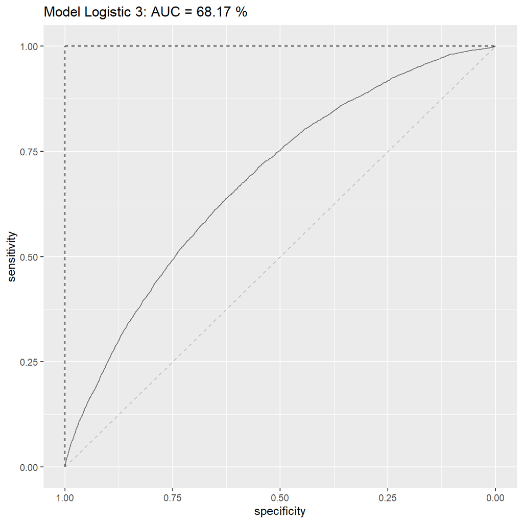

```r
prob_default3<- predict(logistic3, lc_clean, type= "response")

ROC_logistic3 <-roc(lc_clean$default, prob_default3)

#estimate the AUC for Logistic 2 and round it to two decimal places
AUC3<-round(auc(lc_clean$default, prob_default3)*100, digits = 2)
#Plot the ROC curve and display the AUC in the title
ROC3<- ggroc(ROC_logistic3, alpha = 0.5) +
  ggtitle(paste("Model Logistic 3: AUC =", AUC3, "%")) +
    geom_segment(aes(x = 1, xend = 0, y = 0, yend = 1),
               color = "grey", linetype = "dashed") +
    geom_segment(aes(x = 1, xend = 1, y = 0, yend = 1),
               color = "black", linetype = "dashed") +
    geom_segment(aes(x = 1, xend = 0, y = 1, yend = 1),
               color = "black", linetype = "dashed")

ROC3
```

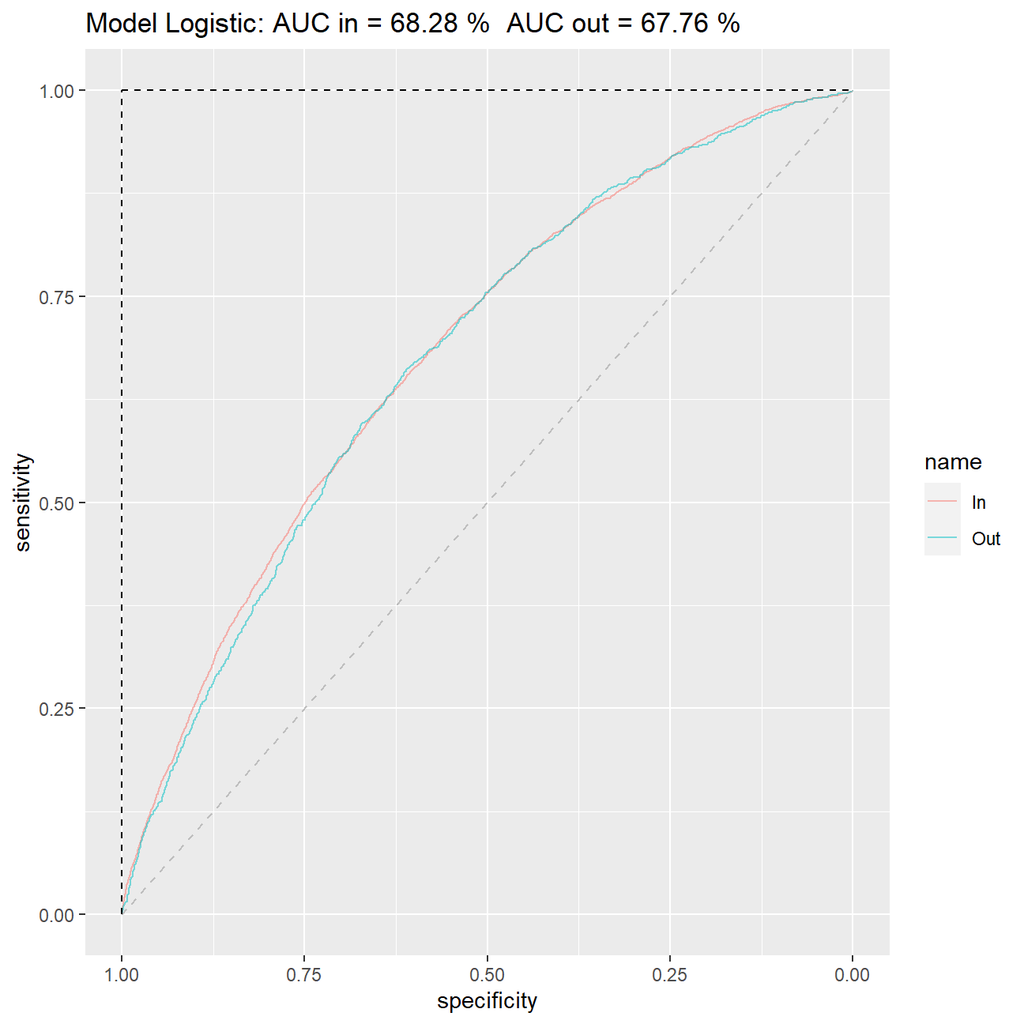

```r
# compare logistic 3's in-sample and out-of-sample performance
# splitting the data into training and testing
set.seed(1234)
train_test_split <- initial_split(lc_clean, prop = 0.8)
testing <- testing(train_test_split) #20% of the data is set aside for testing
training <- training(train_test_split) #80% of the data is set aside for training

# run logistic 3 on the training set
logistic3<- glm(default~I(annual_inc/1000) + term + int_rate + grade + loan_amnt*dti, family="binomial", training)

#calculate probability of default in the training sample
p_in<-predict(logistic3, training, type= "response")

#ROC curve using in-sample predictions
ROC_logistic3_in <- roc(training$default, p_in)
#AUC using in-sample predictions
AUC_logistic3_in<-round(auc(training$default, p_in)*100, digits = 2)

#calculate probability of default out of sample
p_out<- predict(logistic3, testing, type= "response")

#ROC curve using out-of-sample predictions
ROC_logistic3_out <- roc(testing$default, p_out)
#AUC using out-of-sample predictions
AUC_logistic3_out <- round(auc(testing$default, p_out)*100, digits = 2)
#plot in the same figure both ROC curves and print the AUC of both curves in the title
ROCin_out_2<- ggroc(list(In = ROC_logistic3_in, Out = ROC_logistic3_out), alpha = 0.5) +
  ggtitle(paste("Model Logistic: AUC in =", AUC_logistic3_in,"%"," AUC out =", AUC_logistic3_out,"%")) +
    geom_segment(aes(x = 1, xend = 0, y = 0, yend = 1),
               color = "grey", linetype = "dashed") +
    geom_segment(aes(x = 1, xend = 1, y = 0, yend = 1),
               color = "black", linetype = "dashed") +
    geom_segment(aes(x = 1, xend = 0, y = 1, yend = 1),
               color = "black", linetype = "dashed")

ROCin_out_2
```

I chose my best model as logistic 3, still on the basis of a logistic regression. I add another significant feature as int_rate and since loan_amnt itself isn’t significant in our previous models, I tried to find some interaction around it to make better results. So I add another interaction variable to loan_amnt, since I think it will make sense to assume different loan amount would be loaned if there’s a difference in our client’s dti. This interaction turns out to be significant, too. Then I plot the ROC for my best model, estimate in-sample and out-of-sample AUCs and here is a brief summary:

Compared to our previous logistic 2 model, my best model logistic 3 has:

1. My model has a lower AIC: 29250 compared to 29306.
2. My model has a higher in-sample AUC 68.28%, compared to 68.13%.
3. My model has a higher out-of-sample AUC 67.76%, compared to 67.51%.

Then I could conclude my model is better than model logistic 2.

```r
lc_assessment<- read_csv("Assessment Data_2020.csv") %>%  #load the data
  clean_names() %>% # use janitor::clean_names()
  mutate(
    issue_d = mdy(issue_d),  # lubridate::mdy() to fix date format
    term = factor(term_months),     # turn 'term' into a categorical variable
    delinq_2yrs = factor(delinq_2yrs)) # turn 'delinq_2yrs' into a categorical variable

# splitting the data into training and testing
set.seed(1234)
train_test_split <- initial_split(lc_assessment, prop = 0.6)
training <- training(train_test_split) #60% of the data is set aside for training
remaining <- testing(train_test_split) #40% of the data is set aside for validation & testing
set.seed(4321)
train_test_split <- initial_split(remaining, prop = 0.5)
validation<-training(train_test_split) #50% of the remaining data (20% of total data) will be used for validation
testing<-testing(train_test_split) #50% of the remaining data (20% of total data) will be used for testing

#calculate probability of the validation set
p_validation <- predict(logistic3, validation, type= "response")

# adding default probability calculated by validation set to our dataframe.
validation$default_prob <- p_validation

# adding a new column of profit calculated in the method above to our dataframe.
validation <- validation %>%
  mutate(profit = (1-default_prob)*(installment * term_months - loan_amnt) - default_prob * 0.6* loan_amnt)

# selecting the top 200 loans having the most profits.
portfolio_selected <- validation %>%
 arrange(desc(profit)) %>%
 head(200)

# filter the assessment csv using the loan number of portfolio selected
lc_assessment <- lc_assessment %>%
 mutate(tianchi_wu = case_when(
      loan_number %in% portfolio_selected$loan_number ~ 1,
      TRUE ~ 0
  )
)
# wrap up our final file
tianchi_wu <- lc_assessment %>%
 select(loan_number, tianchi_wu)
 write.csv(tianchi_wu,"tianchi_wu.csv",row.names = FALSE)
```